# Ecological and Reproductive Predictors of Brain Size and Shape

Lauren E. Johnson & Donald B. Miles

11/4/2021

load appropriate packages

```r
library(tidyverse)
library(geomorph)
library(ggplot2)
library(cowplot)
library(ape)
library(phytools)
library(geiger)
library(tidytree)
library(picante)
library(pca3d)
library(Rphylopars)
library(dplyr)
library(ggpubr)
library(Hmisc)
library(corrplot)
```

Table of Contents 1) read data 2) remove snakes from dataframe, leaving only lizards 3) convert 2D array to 3D array 4) create individual dataframes for each major brain region

Read in brain data

```r
s1 <- read.csv("./brain_data/whole_brain_coords_S1.csv", stringsAsFactors = F)
```

Remove snakes from dataframe

```r
snakes <- c("Xerotyphlops_vermicularis",
            "Python_regius",
            "Epicrates_cenchria",
            "Eryx_jaculus",
            "Cerastes_cerastes",
            "Hydrophis_platurus",
            "Boaedon_fuliginosus",
            "Chrysopelea_ornata",
            "Dendrelaphis_pictus",
            "Dasypeltis_gansi",
            "Pantherophis_guttatus")

s1.trim <- s1[!((s1$Id) %in% snakes),]
```

Convert 2D array to 3D array

```r
s1.trim.3D <- as.matrix(s1.trim[,-(1)])
s1.trim.3D <- arrayspecs(s1.trim.3D, 61, 3)
```

the 3D array is [a, b, c], where…

a = landmark id (e.g., landmark 1, landmark 2, landmark 3, etc.) with a max of 61 values b = the 3D coordinates (e.g., x coord, y coord, z coord) with a max of 3 values c = species id coded by position in dataframe (e.g., Actonias_meleagris is 1) species id , , 1

3D coordinates [,1] [,2] [,3] landmark 1 [1,] 9104.361 14396.24 7085.975 landmark 2 [2,] 9740.752 13144.82 6818.917

Create individual dataframes for each major brain region source for subsetting 3D arrays: http://adv-r.had.co.nz/Subsetting.html

Which landmarks ids (1 through 61) correspond to what major brain region *3 and 45 are shared between Diencephalon, Mesencephalon, and Medulla Oblongata (even though 3 isn’t duplicated between them in their data - weird)

Telencephalon 1:5, 10:14, 19:26

Diencephalon 6, 15, 43:45, 54:55, 61

Mesencephalon 7:8, 16:17, 27:28, 45, 48:49, 52:53, 58:59

Cerebellum 30:42, 50:51

Medulla oblongota 9, 18, 29, 45:47, 56:57, 60

```r
tel <- s1.trim.3D[c(1:5, 10:14, 19:26), 1:3, 1:29]
dien <- s1.trim.3D[c(6, 15, 43:45, 54:55, 61), 1:3, 1:29]
mes <- s1.trim.3D[c(7:8, 16:17, 27:28, 45, 48:49, 52:53, 58:59), 1:3, 1:29]
cere <-s1.trim.3D[c(30:42, 50:51), 1:3, 1:29]
medob <- s1.trim.3D[c(9, 18, 29, 45:47, 56:57, 60), 1:3, 1:29]
```

Geomorphometric analyses using package ‘geomorph’

Generalized Procrustes Analysis - how we get shape variables from landmark data (refer to gpagen details)

```r
S1.GPA <- gpagen(s1.trim.3D)
```

```
##
## Performing GPA
##
##
## Making projections... Finished!
```

```r
plot(S1.GPA) # ? does this plot all the species on top of each other?
```

[output not shown]

Test the integration of the brain structures (‘quantifying the degree of morphological integration between modular partitions of shape data’)

landmarks of the brain assigned to brain region partitions tel = A dien = B (the shared point 45 is classified under B) mes = C cere = D medob= E

```r
brain.regions <- c('A', 'A', 'A', 'A', 'A',
                   'B',
                   'C', 'C',
                   'E',
                   'A', 'A', 'A', 'A', 'A',
                   'B',
                   'C', 'C',
                   'E',
                   'A', 'A', 'A', 'A', 'A', 'A', 'A', 'A',
                   'C', 'C',
                   'E',
                   'D', 'D', 'D', 'D', 'D', 'D', 'D', 'D', 'D', 'D', 'D', 'D', 'D',
                   'B', 'B', 'B',
                   'E', 'E',
                   'C', 'C',
                   'D', 'D',
                   'C', 'C',
                   'B', 'B',
                   'E', 'E',
                   'C', 'C',
                   'E',
                   'B')

Brain.IT <- integration.test(S1.GPA$coords, partition.gp = brain.regions, iter = 999)
```

```
##
## Random PLS calculations: 1000 permutations.
##
```

```r
summary(Brain.IT)
```

```
##
## Call:
## integration.test(A = S1.GPA$coords, partition.gp = brain.regions,
##     iter = 999)
##
##
##
## r-PLS: 0.858
##
## Effect Size (Z): 5.9071
##
## P-value: 0.001
##
## Based on 1000 random permutations
##
## Pairwise statistics
##
## r-PLS:
##           A         B         C         D
## B 0.8681282
## C 0.9224720 0.8715062
## D 0.8838650 0.9249687 0.8785820
## E 0.9141149 0.8639997 0.7043699 0.7440572
##
## Effect Sizes (Z):
##          A        B        C        D
## B 4.090108
## C 4.375480 3.714537
## D 3.996795 4.640105 3.875144
## E 4.497439 3.910687 2.744514 3.082806
##
## P-values::
##       A     B     C     D
## B 0.001
## C 0.001 0.001
## D 0.001 0.001 0.001
## E 0.001 0.001 0.004 0.001
```

```r
#picknplot.shape(plot(Brain.IT))

Brain.Mod <- modularity.test(S1.GPA$coords, partition.gp = brain.regions, iter = 999)
```

```
##
## Finding the optimal rotation for CR
##
##
## Performing permutations
##
```

```r
summary(Brain.Mod)
```

```
##
## Call:
## modularity.test(A = S1.GPA$coords, partition.gp = brain.regions,
##     iter = 999)
##
##
##
## CR: 0.761
##
## P-value: 0.001
##
## Effect Size: -5.5547
##
## Based on 1000 random permutations
```

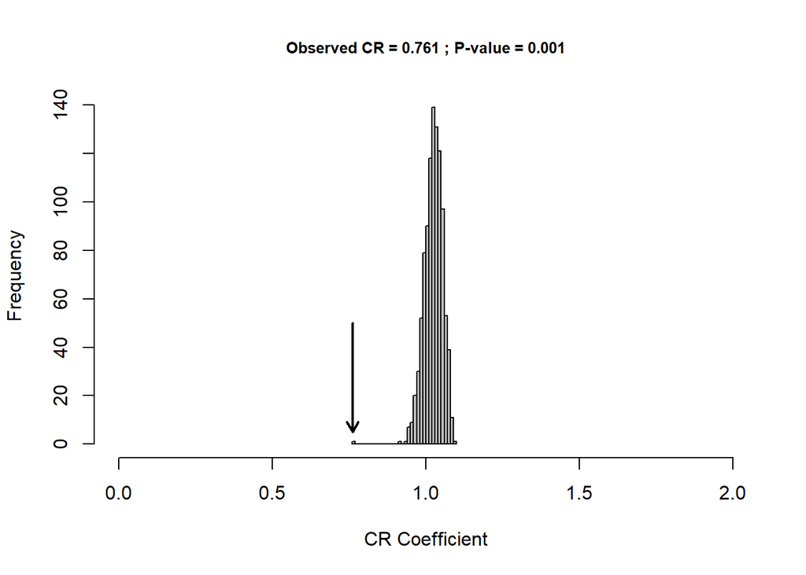

```r
plot(Brain.Mod)
```

Refer to adam dean papers on how to interpret the results Adams, D.C. and M.L. Collyer. 2019. Comparing the strength of modular signal, and evaluating alternative modular hypotheses, using covariance ratio effect sizes with morphometric data. Evolution. 73:2352-2367.